# Predicting Airbnb Prices in Barcelona

Tunay Tokmak

2023-02-12

# DATA

The Airbnb data consists of listings in **Barcelona**. There are 15,778 observations and 75 variables. Variables are related to hosts, reviews, characteristics of the accommodation like how many bathrooms it has or how many bedrooms it has etc. This study is concerned with only entire homes or apartments that host between 2 to 6 accommodates. After filtering the data accordingly , the observation number descreased to 8298.

## Target Variable

The target variable is price of a certain accommodation. The very first step is to understand how it is distributed.After 98th percentile, the price diverts from the trend enormously. Therefore, this values can distort the models. Since those observations account for only 2%, I decided to exclude them from my analysis.Observations with price value smaller than 388 constitue the sample.

## Featured Variables

- The host_location variable of the data includes the information regarding if an host is from Spain or not. I decided to create a dummy variable that takes 1 if the host is local.
- Using host_since and last_scraped date variables, the host_days variable is calculated to indicate the days host present.
- Additionally, amenities variable lists the amenities present in an accommodation. And based on research, amenities like air conditioning, sauna, hot tub, gym, pool, sound system, parking area,balcony, workpace,pets allowed, crib, coffee machine and entertainment tools like Netflix or Amazon Prime are major contributors to the price.Therefore, I decided to create dummy variables out of amenities variable.

**Variables Created Out of Amenities** air_conditioning, sauna,hot_tub, gym,pool, sound_system, parking, balcony, pets,crib, coffee, netflix_amazon.

## Null Values

After elimination of correlated and irrelevant variables, review_scores_rating, host_response_time, host_response_rate, host_acceptance_rate and bedrooms had null values. Since I consider them important variables I decided to impute them.

- review scores rating is imputed with mean and flag_review_scores rating is added.
- bedrooms is imputed with the number of accommodates and flag_bedrooms is added.
- host_response_time is imputed with unknown as a category.
- host_response_rate is imputed with mean and flag added as a variable.
- host_acceptance_rate is imputed with mean and flag added as a variable.

## Outliers

99th percentile of minimum_nights variable is 90, and maximum value is 1125. Only the observations with minimum_nights smaller than 90 are included in the models. Similarly 99th percentile of maximum_nights is 1125 when the maximum value is 3000. Only the observations with maximum nights smaller tham 1125 are kept.

## Observations with Low Occurrence

When property type variable is examined, it is seen that ‘Casa particular’,‘Tiny home’,‘Barn’,‘Entire home/apt’,‘Tent’,‘Camper/RV’ has records less than 4. It can be biased to make inferences about tents or barns based on only one observation. Therefore, I exclued them in my analysis. Bathrooms and bedrooms are treated with the similar logic.

# MODELS

## Random Forest

Random forest model is generated by randomized grid search with 5-fold cross validation. The best model is generated with 400 trees with minimum split of 2. Maximum number of features is the squared root of features.

The **RMSE** is **37.89**

### Model Diagnostics

#### Variance Importance Plot

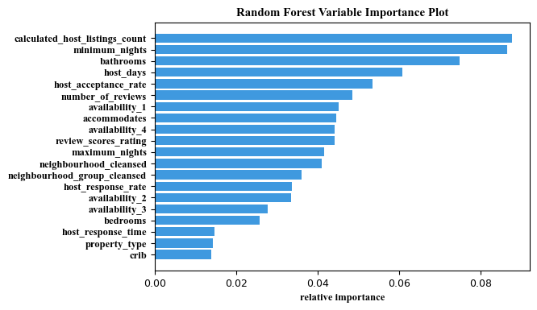

The most important variables occurs to be calculated_host_listings and minimum nights. It is interesting to see that luxury amenities are not that important for the regression.

#### Sub-Sample Analysis

##### Analysis Across Districts

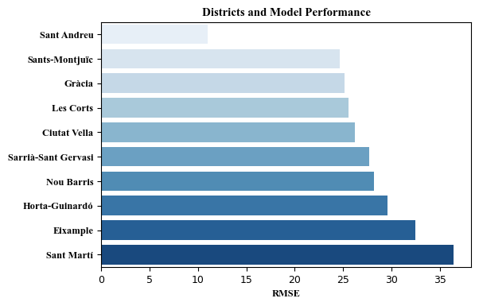

The graph shows that model performs best for Sant Andrau district with RMSE around 11. Eixample and Sant Marti are the districts with the lowest model performances. The remainder districts are close to each other with similar RMSE scores.

##### Analysis Across Property Types

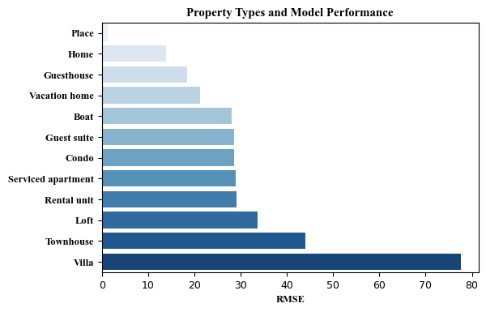

We see that the model performs very badly for villas when it performs pretty well for entire places. However it should be considered that the observation number is not that high for those type of accommodations. The RMSE for rental units is 29.15. This is important because almost 90% of the accommodations are entire rental units. And being the RMSE for rental unit is lower than model RMSE, we can be more confident about our predictions.

## Lasso

To generate the lasso model, 5-fold cross validation method is used. Interaction of neighborhoods and property types added to the model. Only amenity types which displays a considerable difference like sauna,gym and pool are included.

Lasso decreased the coefficients of accommodates and host response time to 0.The model **RMSE** is **50.33**. The best alpha value across folds is 0.12. Below you can see how the MSE changes across folds based on different alpha values.

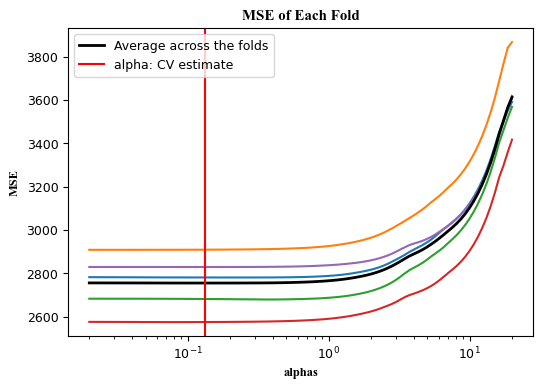

## OLS

OLS is generated based on districts, property types, accommodates, bathrooms, minimum nights,ratings and luxury amenities. The OLS model much more simplified because instead of analyzing each neighborhood, the model only considers districts.

The **RMSE** score of the OLS model with 5-fold crooss validation is **50.89**.

## Model Comparision and Limitations

Comparing the RMSE values of the models,

- Random Forest: 37.89
- Lasso: 50.33
- OLS: 50.89

There is a huge difference between linear models and the random forest. Therefore, I choose random forest. In terms of Lasso and OLS, we see that OLS might be a better choice because it includes fewer interactions and variables but performs quite similar.

This study is limited because

- NLP techniques could be employed to gain further information from columns like neighborhood_review and description.
- The model can be used for only specific types of accommodation types
- Linear models might be repeated with further transformations of the variables.